# Canopy analysis in R using Forest Tools

Andrew Plowright

2020-06-17

## Introduction

The Forest Tools R package offers functions to analyze remotely sensed forest data. Currently, tools to detect dominant treetops and outline tree crowns have been implemented, both of which are applied to a rasterized **canopy height model (CHM)**, which is generally derived from LiDAR or photogrammetric point clouds. A function to summarize the height and count of trees within user-defined geographical areas is also available.

The following vignette provides examples for using these functions.

## Installation

Check that R is up-to-date. This can be done automatically using the `installr` package. Alternatively, download the latest version directly from the [Comprehensive R Archive Network (CRAN)](https://cran.r-project.org/).

```r
install.packages("installr")
library(installr)
updateR()
```

Download and install the Forest Tools package from CRAN using the `install.packages` function.

```r
install.packages("ForestTools")
```

## Loading sample data

A sample canopy height model (CHM) is included in the Forest Tools package. It represents a small 1.5 hectare swath of forest in the Kootenay Mountains, British Columbia. The following examples use this sample, but if you would rather use your own data, it can be loaded into R using the `raster` function. A brief section on reading and writing geospatial data in R is included in this document. Otherwise, begin by loading the necessary libraries and the sample CHM using the `library` and `data` functions respectively.

```r
# Attach the 'ForestTools' and 'raster' libraries
library(ForestTools)
library(raster)

# Load sample canopy height model
data("kootenayCHM")
```

View the CHM using the `plot` function. The cell values are equal to the canopy’s height above ground.

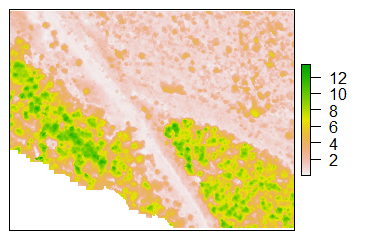

```r
# Remove plot margins (optional)
par(mar = rep(0.5, 4))

# Plot CHM (extra optional arguments remove labels and tick marks from the plot)
plot(kootenayCHM, xlab = "", ylab = "", xaxt='n', yaxt = 'n')
```

## Detecting treetops

Dominant treetops can be detected using `vwf`. This function implements the *variable window filter* algorithm developped by Popescu and Wynne (2004). In short, a moving window scans the CHM, and if a given cell is found to be the highest within the window, it is tagged as a treetop. The size of the window itself changes depending on the height of the cell on which it is centered. This is to compensate for varying crown sizes, with tall trees having wide crowns and vice versa.

Therefore, the first step is to define the **function that will define the dynamic window size**. Essentially, this function should take a **CHM cell value** (i.e.: the height of the canopy above ground at that location) and return the **radius of the search window**. Here, we will define a simple linear equation, but any function with a single input and output will work.

```r
lin <- function(x){x * 0.05 + 0.6}
```

We do not wish for the `vwf` to tag low-lying underbrush or other spurious treetops, and so we also set a minimum height of 2 m using the `minHeight` argument. Any cell with a lower value will not be tagged as a treetop.

```r
ttops <- vwf(CHM = kootenayCHM, winFun = lin, minHeight = 2)
```

We can now plot these treetops on top of the CHM.

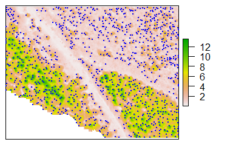

```r
# Plot CHM
plot(kootenayCHM, xlab = "", ylab = "", xaxt='n', yaxt = 'n')
# Add dominant treetops to the plot
plot(ttops, col = "blue", pch = 20, cex = 0.5, add = TRUE)
```

The `ttops` object created by `vwf` in this example contains the spatial coordinates of each detected treetop, as well as two default attributes: *height* and *winRadius*. These correspond to the tree’s height above ground and the radius of the moving window where the tree was located. Note that *winRadius* **is not necessarily equivalent to the tree’s crown radius**.

```r
# Get the mean treetop height
mean(ttops$height)
```

```
## [1] 5.404217
```

## Outlining tree crowns

Canopy height models often represent continuous, dense forests, where tree crowns abut against eachother. Outlining discrete crown shapes from this type of forest is often refered to as *canopy segmentation*, where each crown outline is represented by a *segment*. Once a set of treetops have been detected from a canopy height model, the `mcws` function can be used for this purpose.

The `mcws` function implements the `watershed` algorithm from the [imager](https://cran.r-project.org/package=imager/imager.pdf) library. Watershed algorithms are frequently used in topograhical analysis to outline drainage basins. Given the morphological similarity between an inverted canopy and a terrain model, this same process can be used to outline tree crowns. However, a potential problem is the issue of *oversegmentation*, whereby branches, bumps and other spurious treetops are given their own segments. This source of error can be mitigated by using a variant of the algorithm known as *marker-controlled segmentation* (Beucher & Meyer, 1993), whereby the watershed algorithm is constrained by a set of markers–in this case, treetops.

The `mcws` function also takes a `minHeight` argument, although this value should be lower than that which was assigned to `vwf`. For the latter, `minHeight` defines the lowest expected treetop, whereas for the former it should correspond to the height above ground of the fringes of the lowest trees.

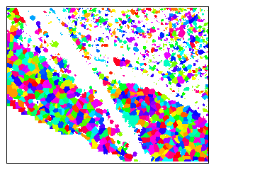

```r
# Create crown map
crowns <- mcws(treetops = ttops, CHM = kootenayCHM, minHeight = 1.5, verbose = FALSE)
# Plot crowns
plot(crowns, col = sample(rainbow(50), length(unique(crowns[])), replace = TRUE), legend = FALSE, xlab = "", ylab = "", xaxt='n', yaxt = 'n')
```

By default, `mcws` returns a raster, where each crown is given a unique cell value. Depending on the intended purpose of the crown map, it may be preferable to store these outlines as polygons. Setting the `format` argument to “polygons” will convert the rasterized crown map to a set of polygons (a [SpatialPolygonsDataFrame](https://cran.r-project.org/package=sp/sp.pdf#page=89)). As an added benefit, these polygons will inherit the attributes of the treetops from which they were generated, such as *height*. Furthermore, an extra attribute, *crownArea*, will be calculated for each polygon.

It should be noted, however, that producing crown outlines as polygons requires significantly more processing time and disk space.

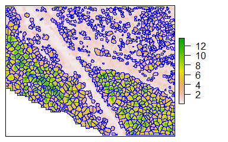

```r
# Create polygon crown map
crownsPoly <- mcws(treetops = ttops, CHM = kootenayCHM, format = "polygons", minHeight = 1.5, verbose = FALSE)
# Plot CHM
plot(kootenayCHM, xlab = "", ylab = "", xaxt='n', yaxt = 'n')
# Add crown outlines to the plot
plot(crownsPoly, border = "blue", lwd = 0.5, add = TRUE)
```

Assuming that each crown has a roughly circular shape, we can use the crown’s area to compute its average circular diameter.

```r
# Compute average crown diameter
crownsPoly[["crownDiameter"]] <- sqrt(crownsPoly[["crownArea"]]/ pi) * 2

# Mean crown diameter
mean(crownsPoly$crownDiameter)
```

```
## [1] 2.882985
```

## Spatial statistics

Managed forests are often divided into discrete spatial units. In British Columbia, for instance, these can range from cut blocks measuring a few hectares to timber supply areas, spanning several hundred square kilometers. The forest composition within these spatial units can be characterized through summarized statistics of tree attributes. For instance, a timber license holder may want a rough estimate of the number of dominant trees within a woodlot, while the standard deviation of tree height is of interest to anyone mapping heterogeneous old growth forest.

The `sp_summarise` function can be used to count trees within a set of spatial units, as well as compute statistics of the trees’ attributes. These spatial units can be in the form of spatial polygons, or can be generated in the form of a raster grid.

When no specific area is defined, `sp_summarise` will simply return the count of all inputted trees.

```r
sp_summarise(ttops)
```

```
##           Value
## TreeCount  1077
```

Tree crowns can also be used as input. By defining the `variables` argument, `sp_summarise` will generate summarized statistics of the trees’ attributes. By default, the mean, median, standard deviation, minimum and maximum are computed, but custom functions can also be used.

```r
sp_summarise(crownsPoly, variables = c("crownArea", "height"))
```

```
##                       Value
## TreeCount       1077.000000
## crownAreaMean      7.454271
## crownAreaMedian    6.250000
## crownAreaSD        5.398044
## crownAreaMin       0.250000
## crownAreaMax      53.000000
## heightMean         5.404217
## heightMedian       4.487972
## heightSD           2.969385
## heightMin          2.002042
## heightMax         13.491207
```

### Statistics by polygon

The Forest Tools package includes the boundaries of three cutting blocks that can be overlayed on `kootenayCHM`. Tree counts and height statistics can be summarized within these boundaries using the `areas` argument.

```r
data("kootenayBlocks")

# Compute tree count and height statistics for cut blocks
blockStats <- sp_summarise(ttops, areas = kootenayBlocks, variables = "height")
```

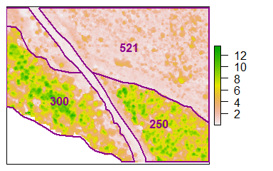

```r
# Plot CHM
plot(kootenayCHM, xlab = "", ylab = "", xaxt='n', yaxt = 'n')
# Add block outlines to the plot
plot(kootenayBlocks, add = TRUE, border =  "darkmagenta", lwd = 2)

# Add tree counts to the plot
library(rgeos)
text(gCentroid(kootenayBlocks, byid = TRUE), blockStats[["TreeCount"]], col = "darkmagenta", font = 2)
```

```r
# View height statistics
blockStats@data
```

```
##   BlockID Shape_Leng Shape_Area TreeCount heightMean heightMedian heightSD
## 0     101   304.3290   3706.389       300   7.538894     7.691572 2.587075
## 1    3308   508.6240   6712.607       521   3.111031     2.771317 1.003606
## 2     113   239.5202   2767.266       250   7.635933     8.180647 2.510343
##   heightMin heightMax
## 0  2.331073 13.491207
## 1  2.002042  7.125149
## 2  2.053920 12.583441
```

### Statistics by grid

Instead of defining polygonal areas, the `sp_summarise` function can also generate counts and stastics in raster format. In this case, the `grid` argument should be used instead of `areas`. If you have an existing raster with the extent, cell size and alignment that you would like to use, it can be input as the `grid` argument. Otherwise, simply entering a numeric value will generate a raster with that cell size.

```r
# Compute tree count within a 10 m x 10 m cell grid
gridCount <- sp_summarise(ttops, grid = 10)
```

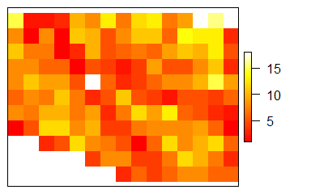

```r
# Plot grid
plot(gridCount, col = heat.colors(255), xlab = "", ylab = "", xaxt='n', yaxt = 'n')
```

If, in addition to tree count, tree attribute statistics are computed, the object returned by `sp_summarise` will be a [RasterBrick](https://cran.r-project.org/package=raster/raster.pdf#page=36), i.e.: a multi-layered raster.

```r
# Compute tree height statistics within a 10 m x 10 m cell grid
gridStats <- sp_summarise(trees = ttops, grid = 10, variables = "height")
```

[output not shown]

```r
# View layer names
names(gridStats)
```

```
## [1] "TreeCount"    "heightMean"   "heightMedian" "heightSD"     "heightMin"
## [6] "heightMax"
```

Use the `[[]]` subsetting operator to extract a single layer.

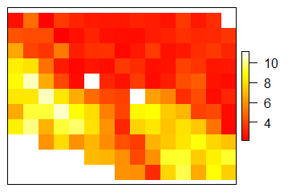

```r
# Plot mean tree height within 10 m x 10 m cell grid
plot(gridStats[["heightMean"]], col = heat.colors(255), xlab = "", ylab = "", xaxt='n', yaxt = 'n')
```

### Using custom functions

By default, the statistics generated by `sp_summarise` for each attribute will be its mean, median, standard deviation, minimum and maximum. However, by using the `statFuns` argument, custom functions can be used instead.

Any custom function should observe the following conditions:

1. It should accept numeric vectors.
2. It should handle NA values.
3. It should have a single argument followed by an ellipsis (three dots). i.e.: `function(x, ...)`
4. It should return a single numeric value.

For instance, the following function will calculate the 98th quantile of a numeric vector.

```r
quant98 <- function(x, ...) quantile(x, c(.98), na.rm = TRUE)
```

To have this function applied using `sp_summarise`, it must be put into a named list. Naming the functions in the list is needed for labelling the function’s outputs.

```r
# Create list of functions
custFuns <- list(quant98, max)
names(custFuns) <- c("98thQuantile", "Max")

# Generate statistics for crown areas and tree heights
sp_summarise(crownsPoly, variables = c("crownArea", "height"), statFuns = custFuns)
```

```
##                            Value
## TreeCount             1077.00000
## crownArea98thQuantile   20.87000
## crownAreaMax            53.00000
## height98thQuantile      11.57175
## heightMax               13.49121
```

## Reading and writing geospatial data in R

### The *raster* and *sp* libraries

The Forest Tools package is built on the raster and sp libraries, which are automatically installed when `ForestTools` is downloaded. These libraries define a variety of classes and functions for working with raster and vector datasets in R.

It is recommended that any user performing geospatial analyses in R be familiar with both of these libraries.

### Geospatial classes used by Forest Tools

[output not shown]

### Raster files

To load a raster file, such as a CHM, use the `raster` function from the `raster` library (both the function and the library have the same name). Simply provide a path to a valid raster file. Don’t forget to use either double backslashes `\\` or forward slashes `/` in the file path.

```r
library(raster)

# Load a canopy height model
inCHM <- raster("C:\\myFiles\\inputs\\testCHM.tif")
```

Once you have performed your analysis, use the `writeRaster` function to save any raster files you have produced. Setting an appropriate [dataType](https://cran.r-project.org/package=raster/raster.pdf#page=65) is optional, but can save disk space.

```r
# Write a crown map raster file
writeRaster(crowns, "C:\\myFiles\\outputs\\crowns.tif", dataType = "INT2U")
```

### Polygon and point files

There are many options for saving point and polygon files to disk. The [rgdal](https://cran.r-project.org/package=rgdal/rgdal.pdf) library provides functions for reading and writing the most common vector formats. The following examples use ESRI Shapefiles.

Use the `readOGR` function to load a polygonal ESRI Shapefile. Instead of providing an entire file path, `readOGR` takes two separate arguments: the file’s directory, followed by the file name *without* an extension. The following would import a file named *“C:\myFiles\blockBoundaries\block375.shp”*.

```r
library(rgdal)

# Load the 'block375.shp' file
blk375boundary <- readOGR("C:\\myFiles\\blockBoundaries", "block375")
```

Follow this same convention for saving a vector file to disk using `writeOGR`. A `driver` must also be specified.

```r
# Save a set of dominant treetops
writeOGR(ttops, "C:\\myFiles\\outputs", "treetops", driver = "ESRI Shapefile")
```

## References

Popescu, S. C., & Wynne, R. H. (2004). [Seeing the trees in the forest](http://www.ingentaconnect.com/content/asprs/pers/2004/00000070/00000005/art00003). *Photogrammetric Engineering & Remote Sensing, 70*(5), 589-604.

Beucher, S., and Meyer, F. (1993). [The morphological approach to segmentation: the watershed transformation](https://www.researchgate.net/profile/Serge_Beucher/publication/233950923_Segmentation_The_Watershed_Transformation_Mathematical_Morphology_in_Image_Processing/links/55f7c6ce08aeba1d9efe4072.pdf). *Mathematical morphology in image processing*, 433-481.